# HW-2-Feature_Selection

```python
import pandas as pd
import numpy as np

import ssl
ssl._create_default_https_context = ssl._create_unverified_context
#urlopen 需驗證SSL證書，將其改為不需要驗證

wine = pd.read_csv('https://archive.ics.uci.edu/ml/machine-learning-databases/wine/wine.data', header = None)

wine.columns = ['Class label', 'Alcohol', 'Malic acid', 'Ash', 'Alcalinity of ash', 'Magnesium', 'Total phenols', 'Flavanoids', 'Nonflavanoid phenols', 'Proanthocyanins', 'Color intensity', 'Hue', 'OD280/0D315 of diluted wines', 'Proline']

# print('Class labels', np.unique(df_wine['Class label']))
wine.head()
```

|  | Class label | Alcohol | Malic acid | Ash | Alcalinity of ash | Magnesium | Total phenols | Flavanoids | Nonflavanoid phenols | Proanthocyanins | Color intensity | Hue | OD280/0D315 of diluted wines | Proline |
| --- | --- | --- | --- | --- | --- | --- | --- | --- | --- | --- | --- | --- | --- | --- |
| 0 | 1 | 14.23 | 1.71 | 2.43 | 15.6 | 127 | 2.80 | 3.06 | 0.28 | 2.29 | 5.64 | 1.04 | 3.92 | 1065 |
| 1 | 1 | 13.20 | 1.78 | 2.14 | 11.2 | 100 | 2.65 | 2.76 | 0.26 | 1.28 | 4.38 | 1.05 | 3.40 | 1050 |
| 2 | 1 | 13.16 | 2.36 | 2.67 | 18.6 | 101 | 2.80 | 3.24 | 0.30 | 2.81 | 5.68 | 1.03 | 3.17 | 1185 |
| 3 | 1 | 14.37 | 1.95 | 2.50 | 16.8 | 113 | 3.85 | 3.49 | 0.24 | 2.18 | 7.80 | 0.86 | 3.45 | 1480 |
| 4 | 1 | 13.24 | 2.59 | 2.87 | 21.0 | 118 | 2.80 | 2.69 | 0.39 | 1.82 | 4.32 | 1.04 | 2.93 | 735 |

### Partition a dataset in training and test sets.

```python
from sklearn.model_selection import train_test_split


X, y = wine.iloc[:, 1:].values, wine.iloc[:, 0].values

# 三七分測試資料訓練資料
X_train, X_test, y_train, y_test = train_test_split(X, y, test_size=0.3, random_state=0)
```

```python
from sklearn.ensemble import RandomForestClassifier

feat_labels = wine.columns[1:]

forest = RandomForestClassifier(n_estimators=1000, random_state=0, n_jobs=-1)

forest.fit(X_train, y_train)
```

```
RandomForestClassifier(n_estimators=1000, n_jobs=-1, random_state=0)
```

### Bringing features onto the same scale => Normalization or Standardization

```python
# Standardization
from sklearn.preprocessing import StandardScaler

stdsc = StandardScaler()
X_train_std = stdsc.fit_transform(X_train)
X_test_std = stdsc.transform(X_test)

# Normalization
from  sklearn.preprocessing import MinMaxScaler
mms = MinMaxScaler()
X_train_norm = mms.fit_transform(X_train)
X_test_norm = mms.transform(X_test)
```

## 合併後的典型目的

#### 1. 一致性可視化

合併標準化後的數據可以確保資料在相同的標準化尺度下顯示 直觀地比較模型在訓練和測試資料上的表現

#### 2. 避免數據偏移

數據集遵循相同的縮放比例

```python
# Normalization
from  sklearn.preprocessing import MinMaxScaler
mms = MinMaxScaler()
X_train_norm = mms.fit_transform(X_train_std)
X_test_norm = mms.transform(X_test_std)

# 合併標準化後的訓練和測試資料
X_combined_std = np.vstack((X_train_norm, X_test_norm))
y_combined = np.hstack((y_train, y_test))
```

# Sequential Backward Selection

**特徵選擇演算法，經由特徵選擇(feature selection)來對資料進行降維(dimensionality reduction)，以達到減少模型複雜度、提高模型泛化程度避免overfitting的效果**

1. 以k=d初始化演算法，其中d代表特徵空間的維度
2. 找出能最大化準則的特徵
3. 將該特徵從特徵空間中移除
4. 重複2、3步驟直到k等於所需特徵數時停止

```python
from sklearn.base import clone
from itertools import combinations
from sklearn.model_selection import train_test_split
from sklearn.metrics import accuracy_score
from sklearn.base import clone

class SBS():
    def __init__(self, estimator, k_features, scoring=accuracy_score,
                 test_size=0.25, random_state=1):
        self.scoring = scoring
        self.estimator = clone(estimator)
        self.k_features = k_features
        self.test_size = test_size
        self.random_state = random_state

    def fit(self, X, y):

        X_train, X_test, y_train, y_test = \
            train_test_split(X, y, test_size=self.test_size,
                             random_state=self.random_state)

        dim = X_train.shape[1]
        self.indices_ = tuple(range(dim))
        self.subsets_ = [self.indices_]
        score = self._calc_score(X_train, y_train,
                                 X_test, y_test, self.indices_)
        self.scores_ = [score]

        while dim > self.k_features:
            scores = []
            subsets = []

            for p in combinations(self.indices_, r=dim - 1):
                score = self._calc_score(X_train, y_train,
                                         X_test, y_test, p)
                scores.append(score)
                subsets.append(p)

            best = np.argmax(scores)
            self.indices_ = subsets[best]
            self.subsets_.append(self.indices_)
            dim -= 1

            self.scores_.append(scores[best])
        self.k_score_ = self.scores_[-1]

        return self

    def transform(self, X):
        return X[:, self.indices_]

    def _calc_score(self, X_train, y_train, X_test, y_test, indices):
        self.estimator.fit(X_train[:, indices], y_train)
        y_pred = self.estimator.predict(X_test[:, indices])
        score = self.scoring(y_test, y_pred)
        return score
```

```python
# 定義plot_decision_region函數
import matplotlib.pyplot as plt
from matplotlib.colors import ListedColormap

def plot_decision_region(X, y, classifier, test_idx=None, resolution=0.02):
    markers = ('s', 'x', 'o', '^', 'v')
    colors = ('red', 'blue', 'lightgreen', 'gray', 'cyan')
    cmap = ListedColormap(colors[:len(np.unique(y))])

    x1_min, x1_max = X[:, 0].min() - 1, X[:, 0].max() + 1
    x2_min, x2_max = X[:, 1].min() - 1, X[:, 1].max() + 1
    xx1, xx2 = np.meshgrid(np.arange(x1_min, x1_max, resolution),
                           np.arange(x2_min, x2_max, resolution))
    Z = classifier.predict(np.array([xx1.ravel(), xx2.ravel()]).T)
    Z = Z.reshape(xx1.shape)
    plt.contourf(xx1, xx2, Z, alpha=0.3, cmap=cmap)
    plt.xlim(xx1.min(), xx1.max())
    plt.ylim(xx2.min(), xx2.max())

    for idx, cl in enumerate(np.unique(y)):
        marker = markers[idx]
        if marker == 'x':
            plt.scatter(x=X[y == cl, 0],
                        y=X[y == cl, 1],
                        alpha=0.8,
                        c=colors[idx],
                        marker=marker,
                        label=cl)
        else:
            plt.scatter(x=X[y == cl, 0],
                        y=X[y == cl, 1],
                        alpha=0.8,
                        c=colors[idx],
                        marker=marker,
                        label=cl,
                        edgecolor='black')

    if test_idx:
        X_test, y_test = X[test_idx, :], y[test_idx]
        plt.scatter(X_test[:, 0], X_test[:, 1], c='none', edgecolor='black', alpha=1.0,
                    linewidth=1, marker='o', s=100, label='test set')
```

```python
from sklearn.neighbors import KNeighborsClassifier

# 使用SBS選取重要特徵
knn = KNeighborsClassifier(n_neighbors=5)
sbs = SBS(knn, k_features=5)
sbs.fit(X_train_std, y_train)

# 選取前5個重要特徵
k5 = list(sbs.subsets_[-1])
feature_names_k5 = [wine.columns[i+1] for i in k5]  # +1 因為第一列是Class label
print(f'Selected features (indices): {k5}')
print(f'Selected features (names): {feature_names_k5}')

# 使用選取的5個重要特徵進行訓練和測試
knn.fit(X_train_std[:, k5], y_train)
print(f'KNN training accuracy with 5 features: {knn.score(X_train_std[:, k5], y_train)}')
print(f'KNN test accuracy with 5 features: {knn.score(X_test_std[:, k5], y_test)}')

# 選取前2個重要特徵
k2 = list(sbs.subsets_[-3])[:2]
feature_names_k2 = [wine.columns[i + 1] for i in k2]  # +1 因為第一列是Class label

print(f'\nSelected features by KNN (indices): {k2}')
print(f'Selected features by KNN (names): {feature_names_k2}')


# 使用選取的2個重要特徵進行訓練和測試
knn.fit(X_train_std[:, k2], y_train)
print(f'KNN training accuracy with 2 features: {knn.score(X_train_std[:, k2], y_train)}')
print(f'KNN test accuracy with 2 features: {knn.score(X_test_std[:, k2], y_test)}')
```

```
Selected features (indices): [0, 1, 5, 7, 9]
Selected features (names): ['Alcohol', 'Malic acid', 'Total phenols', 'Nonflavanoid phenols', 'Color intensity']
KNN training accuracy with 5 features: 0.9112903225806451
KNN test accuracy with 5 features: 0.9444444444444444

Selected features by KNN (indices): [0, 1]
Selected features by KNN (names): ['Alcohol', 'Malic acid']
KNN training accuracy with 2 features: 0.8225806451612904
KNN test accuracy with 2 features: 0.8518518518518519
```

```python
# 使用隨機森林列出特徵的重要性
forest = RandomForestClassifier(n_estimators=500, random_state=1)
forest.fit(X_train, y_train)
importances = forest.feature_importances_
indices = np.argsort(importances)[::-1]

# 列出前兩個重要特徵
top2_indices = indices[:2]
feature_names_top2 = [wine.columns[i+1] for i in top2_indices]  # +1 因為第一列是Class label
print(f'Feature ranking (indices): {indices}')
print(f'Top 2 features (indices): {top2_indices}')
print(f'Top 2 features (names): {feature_names_top2}')
```

```
Feature ranking (indices): [ 9 12 11  6  0 10  5  3  1  8  4  7  2]
Top 2 features (indices): [ 9 12]
Top 2 features (names): ['Color intensity', 'Proline']
```

```python
from sklearn.linear_model import Perceptron, LogisticRegression
from sklearn.svm import SVC
from sklearn.tree import DecisionTreeClassifier
from sklearn.ensemble import RandomForestClassifier
from sklearn.base import clone
from sklearn.metrics import accuracy_score, precision_score, recall_score, f1_score
# 訓練和評估六種不同的機器學習演算法
classifiers = {
    'Perceptron': Perceptron(max_iter=100, eta0=0.01, random_state=0),
    'Logistic Regression': LogisticRegression(C=1.0, random_state=0),
    'SVM': SVC(kernel='linear', C=0.1, random_state=0),
    'Decision Tree': DecisionTreeClassifier(criterion='gini', splitter='random', max_depth=10, min_samples_split=5, random_state=0),
    'Random Forest': RandomForestClassifier(criterion='gini', n_estimators=100, max_depth=3, random_state=0, n_jobs=2),
    'KNN': KNeighborsClassifier(n_neighbors=50, p=2, metric='minkowski')
}
```

```
Perceptron with SBS features - Train Accuracy: 0.645, Test Accuracy: 0.722
```

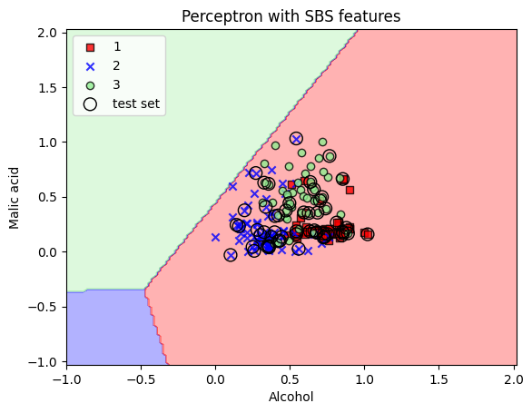

```
Logistic Regression with SBS features - Train Accuracy: 0.790, Test Accuracy: 0.778
```

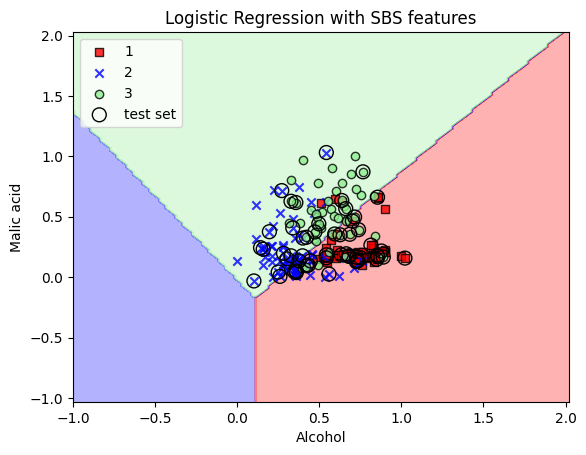

```
SVM with SBS features - Train Accuracy: 0.806, Test Accuracy: 0.796
```

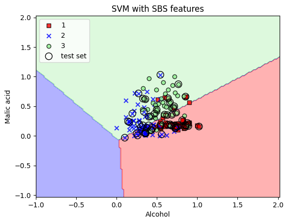

```
Decision Tree with SBS features - Train Accuracy: 0.863, Test Accuracy: 0.852
```

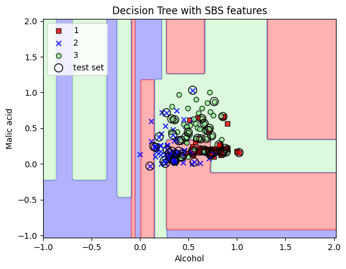

```
Random Forest with SBS features - Train Accuracy: 0.863, Test Accuracy: 0.870
```

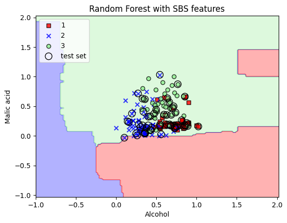

```
KNN with SBS features - Train Accuracy: 0.806, Test Accuracy: 0.833
```

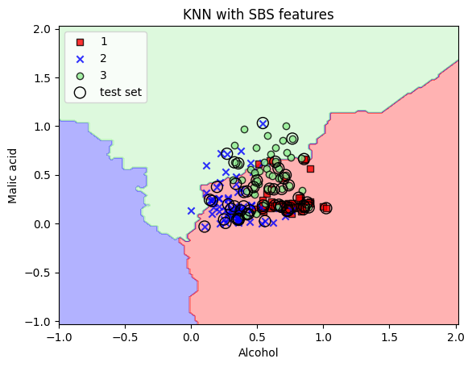

```
Perceptron with RF features - Train Accuracy: 0.911, Test Accuracy: 0.852
```

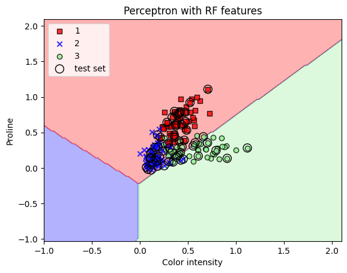

```
Logistic Regression with RF features - Train Accuracy: 0.895, Test Accuracy: 0.889
```

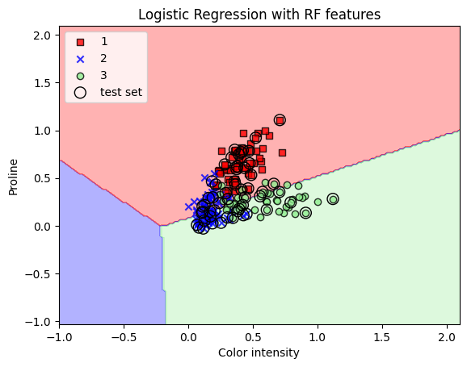

```
SVM with RF features - Train Accuracy: 0.879, Test Accuracy: 0.852
```

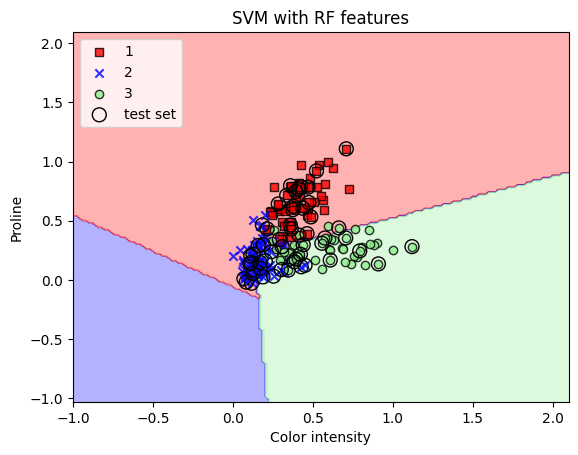

```
Decision Tree with RF features - Train Accuracy: 0.911, Test Accuracy: 0.815
```

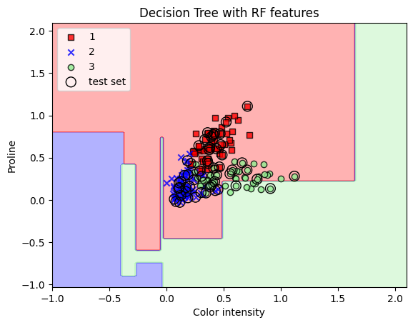

```
Random Forest with RF features - Train Accuracy: 0.935, Test Accuracy: 0.870
```

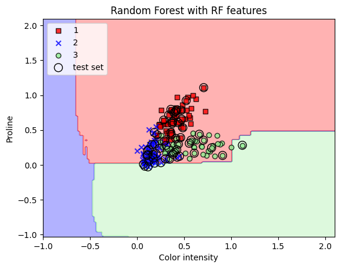

```
KNN with RF features - Train Accuracy: 0.879, Test Accuracy: 0.852
```

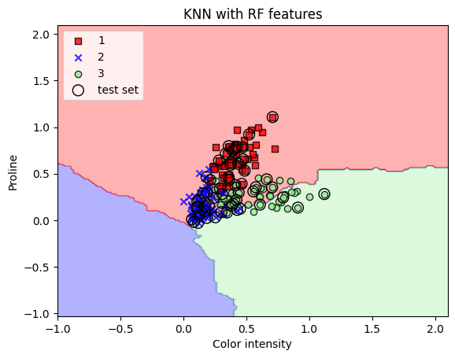

```python
results_knn_features = []
results_rf_features = []

# 使用KNN選取的前兩個重要特徵進行訓練和測試
for name, clf in classifiers.items():
    clf = clone(clf)  # 重新初始化分類器
    clf.fit(X_train_std[:, k2], y_train)

    # 訓練準確率
    y_train_pred = clf.predict(X_train_std[:, k2])
    train_accuracy = accuracy_score(y_train, y_train_pred)

    # 測試準確率
    y_test_pred = clf.predict(X_test_std[:, k2])
    test_accuracy = accuracy_score(y_test, y_test_pred)

    # 其他評估指標
    precision = precision_score(y_test, y_test_pred, average='macro')
    recall = recall_score(y_test, y_test_pred, average='macro')
    f1 = f1_score(y_test, y_test_pred, average='macro')

    results_knn_features.append((name, train_accuracy, test_accuracy, precision, recall, f1))

    print(f"{name} with SBS features - Train Accuracy: {train_accuracy:.3f}, Test Accuracy: {test_accuracy:.3f}")

    plot_decision_region(X_combined_std[:, k2], y_combined, classifier=clf, test_idx=range(len(y_train), len(y_combined)))
    plt.title(f"{name} with SBS features")
    plt.xlabel(wine.columns[k2[0]+1])
    plt.ylabel(wine.columns[k2[1]+1])
    plt.legend(loc='upper left')
    plt.show()

# 使用隨機森林選取的前兩個重要特徵進行訓練和測試
for name, clf in classifiers.items():
    clf = clone(clf)  # 重新初始化分類器
    clf.fit(X_train_std[:, top2_indices], y_train)

    # 訓練準確率
    y_train_pred = clf.predict(X_train_std[:, top2_indices])
    train_accuracy = accuracy_score(y_train, y_train_pred)

    # 測試準確率
    y_test_pred = clf.predict(X_test_std[:, top2_indices])
    test_accuracy = accuracy_score(y_test, y_test_pred)

    # 其他評估指標
    precision = precision_score(y_test, y_test_pred, average='macro')
    recall = recall_score(y_test, y_test_pred, average='macro')
    f1 = f1_score(y_test, y_test_pred, average='macro')

    results_rf_features.append((name, train_accuracy, test_accuracy, precision, recall, f1))

    print(f"{name} with RF features - Train Accuracy: {train_accuracy:.3f}, Test Accuracy: {test_accuracy:.3f}")

    plot_decision_region(X_combined_std[:, top2_indices], y_combined, classifier=clf, test_idx=range(len(y_train), len(y_combined)))
    plt.title(f"{name} with RF features")
    plt.xlabel(wine.columns[top2_indices[0]+1])
    plt.ylabel(wine.columns[top2_indices[1]+1])
    plt.legend(loc='upper left')
    plt.show()
```

```python
# 顯示結果
print("Summary of accuracies with KNN features:")
for result in results_knn_features:
    name, train_accuracy, test_accuracy, precision, recall, f1 = result
    print(f"{name}: Train Accuracy={train_accuracy:.3f}, Test Accuracy={test_accuracy:.3f}, Precision={precision:.3f}, Recall={recall:.3f}, F1 Score={f1:.3f}")

print("\nSummary of accuracies with RF features:")
for result in results_rf_features:
    name, train_accuracy, test_accuracy, precision, recall, f1 = result
    print(f"{name}: Train Accuracy={train_accuracy:.3f}, Test Accuracy={test_accuracy:.3f}, Precision={precision:.3f}, Recall={recall:.3f}, F1 Score={f1:.3f}")

# 將結果整理成表格
results_knn_df = pd.DataFrame(results_knn_features, columns=['Algorithm', 'Train Accuracy', 'Test Accuracy', 'Precision', 'Recall', 'F1 Score'])
results_rf_df = pd.DataFrame(results_rf_features, columns=['Algorithm', 'Train Accuracy', 'Test Accuracy', 'Precision', 'Recall', 'F1 Score'])

print("\nResults with SBS features:")
print(results_knn_df)

print("\nResults with RF features:")
print(results_rf_df)
```

```
Summary of accuracies with KNN features:
Perceptron: Train Accuracy=0.645, Test Accuracy=0.722, Precision=0.735, Recall=0.710, F1 Score=0.696
Logistic Regression: Train Accuracy=0.790, Test Accuracy=0.778, Precision=0.763, Recall=0.748, F1 Score=0.751
SVM: Train Accuracy=0.806, Test Accuracy=0.796, Precision=0.776, Recall=0.774, F1 Score=0.773
Decision Tree: Train Accuracy=0.863, Test Accuracy=0.852, Precision=0.831, Recall=0.824, F1 Score=0.825
Random Forest: Train Accuracy=0.863, Test Accuracy=0.870, Precision=0.856, Recall=0.847, F1 Score=0.851
KNN: Train Accuracy=0.806, Test Accuracy=0.833, Precision=0.820, Recall=0.809, F1 Score=0.810

Summary of accuracies with RF features:
Perceptron: Train Accuracy=0.911, Test Accuracy=0.852, Precision=0.843, Recall=0.853, F1 Score=0.846
Logistic Regression: Train Accuracy=0.895, Test Accuracy=0.889, Precision=0.890, Recall=0.902, F1 Score=0.888
SVM: Train Accuracy=0.879, Test Accuracy=0.852, Precision=0.851, Recall=0.851, F1 Score=0.849
Decision Tree: Train Accuracy=0.911, Test Accuracy=0.815, Precision=0.801, Recall=0.802, F1 Score=0.800
Random Forest: Train Accuracy=0.935, Test Accuracy=0.870, Precision=0.866, Recall=0.879, F1 Score=0.866
KNN: Train Accuracy=0.879, Test Accuracy=0.852, Precision=0.852, Recall=0.840, F1 Score=0.845

Results with SBS features:
             Algorithm  Train Accuracy  Test Accuracy  Precision    Recall  \
0           Perceptron        0.645161       0.722222   0.734568  0.709790
1  Logistic Regression        0.790323       0.777778   0.762664  0.748068
2                  SVM        0.806452       0.796296   0.775763  0.773709
3        Decision Tree        0.862903       0.851852   0.831169  0.823948
4        Random Forest        0.862903       0.870370   0.856481  0.847197
5                  KNN        0.806452       0.833333   0.819960  0.808796

   F1 Score
0  0.695821
1  0.751047
2  0.773382
3  0.825253
4  0.850654
5  0.809524

Results with RF features:
             Algorithm  Train Accuracy  Test Accuracy  Precision    Recall  \
0           Perceptron        0.911290       0.851852   0.842690  0.853024
1  Logistic Regression        0.895161       0.888889   0.889823  0.901914
2                  SVM        0.879032       0.851852   0.850993  0.850632
3        Decision Tree        0.911290       0.814815   0.800611  0.801742
4        Random Forest        0.935484       0.870370   0.865898  0.878665
5                  KNN        0.879032       0.851852   0.851852  0.840142

   F1 Score
0  0.845865
1  0.888224
2  0.849383
3  0.799817
4  0.865656
5  0.844810
```